# Examen Argumentativo

Cesar Vazquez - A01197857

2022-12-01

## Problema 1

Se afirma que la puntuación emitida por la Prueba de inteligencia IQ de Wechsler tiene una media de 100, con distribución normal. A una muestra aleatoria de 13 personas se les aplicó la prueba y se obtuvieron los siguientes resultados:

101, 88, 126, 109, 118, 93, 144, 96, 93, 102, 102, 140, 117

Haz una estimación por intervalo de la verdadera media de la puntuación de la prueba con un nivel de confianza del 91%. Escribe tu respuesta redondeada a 2 decimales. Separa la cota inferior de la superior con una coma y emite tu respuesta entre corchetes.

```r
mediaPersonas = c(101,88, 126, 109, 118, 93, 144, 96, 93, 102, 102, 140, 117)
media = mean(mediaPersonas);
varianza = var(mediaPersonas);
std = sqrt(varianza);
```

```r
qnorm(pnorm(0.045), mean = media, sd = std)
```

```
## [1] 110.7336
```

```r
qnorm(pnorm(1-0.045), mean = media, sd = std)
```

```
## [1] 127.124
```

¿Es factible suponer que la media de la puntuación es correcta? No ¿Por qué? No esta dentro de los limites

## Problema 2

Los datos se refieren al consumo de combustible del ciclo urbano en millas por galón (mpg) y 8 atributos (variables) de los automóviles. Los datos son los siguientes

V1. mpg: millas por galón  
V2. cilindros: número de cilindros  
V3. mileage: número de millas recorridas  
V4. horsepower: caballos de fuerza  
V5. weight: peso en libras  
V6. acceleration: aceleración  
V7. model_year  
V8. origin: nacional, extranjero, desconocido  
V9. car name: marca, tipo

1. Lea los datos y asegúrese que estén limpios.

```r
library(ggplot2)
M = read.csv("data2.1-3.csv")
M
```

```
##       V1 V2    V3  V4   V5   V6 V7 V8                                   V9
## 1   18.0  8 307.0 130 3504 12.0 70  1            chevrolet chevelle malibu
## 2   15.0  8 350.0 165 3693 11.5 70  1                    buick skylark 320
## 3   18.0  8 318.0 150 3436 11.0 70  1                   plymouth satellite
## 4   16.0  8 304.0 150 3433 12.0 70  1                        amc rebel sst
## 5   17.0  8 302.0 140 3449 10.5 70  1                          ford torino
## 6   15.0  8 429.0 198 4341 10.0 70  1                     ford galaxie 500
## 7   14.0  8 454.0 220 4354  9.0 70  1                     chevrolet impala
## 8   14.0  8 440.0 215 4312  8.5 70  1                    plymouth fury iii
## 9   14.0  8 455.0 225 4425 10.0 70  1                     pontiac catalina
## 10  15.0  8 390.0 190 3850  8.5 70  1                   amc ambassador dpl
## 11    NA  4 133.0 115 3090 17.5 70  2                 citroen ds-21 pallas
## 12    NA  8 350.0 165 4142 11.5 70  1     chevrolet chevelle concours (sw)
## 13    NA  8 351.0 153 4034 11.0 70  1                     ford torino (sw)
## 14    NA  8 383.0 175 4166 10.5 70  1              plymouth satellite (sw)
```

[output cut: 392 more lines]

```r
sum(is.na(M))
```

```
## [1] 14
```

```r
nrow(M)
```

```
## [1] 406
```

```r
M = na.omit(M)
nrow(M)
```

```
## [1] 392
```

```r
sum(is.na(M))
```

```
## [1] 0
```

Tiene 14 valores nulos, se eliminaron y queda un total de 392 muestras.

2. Reduzca la matriz de datos original a otra base sólo de variables numéricas.

```r
Num = M[,-9]
```

3. Elija la variable V3 como variable dependiente, determine un modelo adecuado para el análisis y responda a las siguientes preguntas:

```r
y = M$V3
modelo <- lm(M$V3~M$V1 + M$V2 + M$V4 + M$V5 + M$V6 + M$V7)
```

1. Determine los coeficientes estimados de todas las variables de tu nueva base de datos construida. (La base que solo tiene variables numéricas)

```r
summary(modelo)
```

```
##
## Call:
## lm(formula = M$V3 ~ M$V1 + M$V2 + M$V4 + M$V5 + M$V6 + M$V7)
##
## Residuals:
##     Min      1Q  Median      3Q     Max
## -80.763 -11.534   0.709  12.027 115.725
##
## Coefficients:
##               Estimate Std. Error t value Pr(>|t|)
## (Intercept) -67.786193  33.167911  -2.044   0.0417 *
## M$V1          0.367364   0.352021   1.044   0.2973
## M$V2         30.279858   1.705540  17.754  < 2e-16 ***
## M$V4          0.445570   0.092973   4.792 2.36e-06 ***
## M$V5          0.042524   0.004745   8.961  < 2e-16 ***
## M$V6         -1.565056   0.701893  -2.230   0.0263 *
## M$V7         -0.802170   0.448690  -1.788   0.0746 .
## ---
## Signif. codes:  0 '***' 0.001 '**' 0.01 '*' 0.05 '.' 0.1 ' ' 1
##
## Residual standard error: 23.76 on 385 degrees of freedom
## Multiple R-squared:  0.9492, Adjusted R-squared:  0.9484
## F-statistic:  1200 on 6 and 385 DF,  p-value: < 2.2e-16
```

2. Utilice el criterio de Akaike para determinar la selección de predictores y búsqueda en ambas direcciones, forward y backward. Describa cuál es la ecuación del nuevo modelo que mejor explica la variable respuesta. ¿Qué puede decir de los p-value individuales?

```r
step(object = modelo, direction = "both", trace =1)
```

```
## Start:  AIC=2490.69
## M$V3 ~ M$V1 + M$V2 + M$V4 + M$V5 + M$V6 + M$V7
##
##        Df Sum of Sq    RSS    AIC
## - M$V1  1       615 217985 2489.8
## <none>              217370 2490.7
## - M$V7  1      1805 219175 2491.9
## - M$V6  1      2807 220177 2493.7
## - M$V4  1     12968 230338 2511.4
## - M$V5  1     45338 262708 2562.9
## - M$V2  1    177960 395331 2723.2
##
## Step:  AIC=2489.8
## M$V3 ~ M$V2 + M$V4 + M$V5 + M$V6 + M$V7
##
##        Df Sum of Sq    RSS    AIC
## <none>              217985 2489.8
## - M$V7  1      1190 219175 2489.9
## + M$V1  1       615 217370 2490.7
## - M$V6  1      2715 220700 2492.7
## - M$V4  1     13034 231019 2510.6
## - M$V5  1     52571 270556 2572.5
## - M$V2  1    177611 395596 2721.4
```

```
##
## Call:
## lm(formula = M$V3 ~ M$V2 + M$V4 + M$V5 + M$V6 + M$V7)
##
## Coefficients:
## (Intercept)         M$V2         M$V4         M$V5         M$V6         M$V7
##   -73.33278     30.24399      0.44669      0.04014     -1.53807     -0.52690
```

3. Describa los nuevos coeficientes estimados y el error estándar de cada variable después de aplicar el criterio de Akaike para la selección de predictores en la dirección de búsqueda que eligió.

```r
modelo2 <- lm(M$V3~M$V1+M$V6+M$V7)
summary(modelo2)
```

```
##
## Call:
## lm(formula = M$V3 ~ M$V1 + M$V6 + M$V7)
##
## Residuals:
##      Min       1Q   Median       3Q      Max
## -188.172  -34.149    1.289   26.713  208.214
##
## Coefficients:
##             Estimate Std. Error t value Pr(>|t|)
## (Intercept) 239.6723    66.9339   3.581 0.000386 ***
## M$V1        -10.6198     0.4712 -22.538  < 2e-16 ***
## M$V6         -9.7179     1.1342  -8.568 2.52e-16 ***
## M$V7          4.6691     0.9452   4.940 1.16e-06 ***
## ---
## Signif. codes:  0 '***' 0.001 '**' 0.01 '*' 0.05 '.' 0.1 ' ' 1
##
## Residual standard error: 55.96 on 388 degrees of freedom
## Multiple R-squared:  0.7163, Adjusted R-squared:  0.7141
## F-statistic: 326.5 on 3 and 388 DF,  p-value: < 2.2e-16
```

4. Muestre a través de gráficos, los residuales individuales de cada variable en el nuevo modelo. Interprételos.

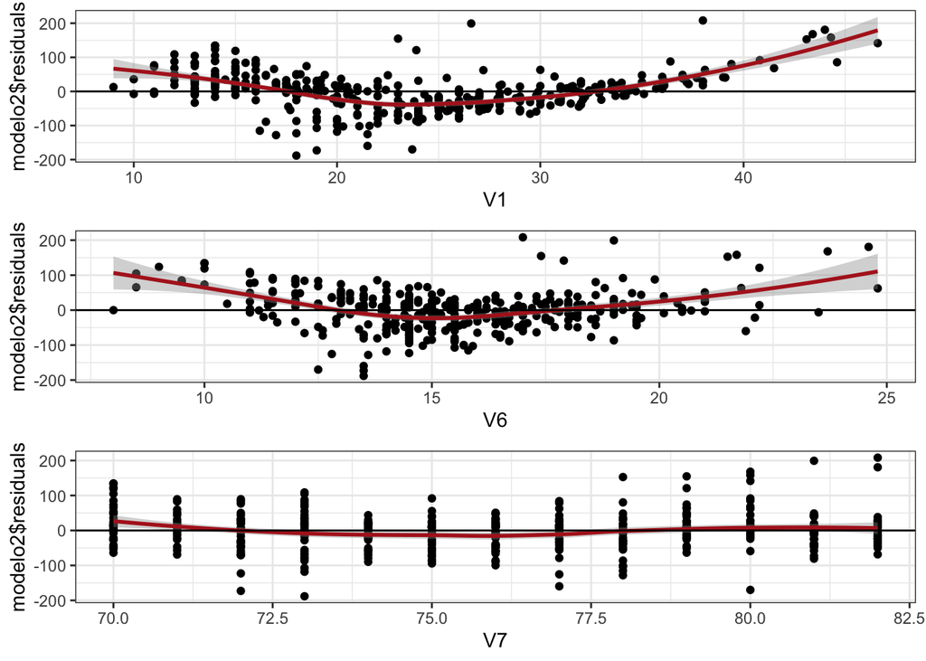

```r
library(ggplot2)
library(gridExtra)

plot1 <- ggplot(data=M, aes(V1, modelo2$residuals))+ geom_point() + geom_smooth(color = "firebrick") + geom_hline(yintercept=0)+ theme_bw()
plot2 <- ggplot(data=M, aes(V6, modelo2$residuals))+ geom_point() + geom_smooth(color = "firebrick") + geom_hline(yintercept=0)+ theme_bw()
plot3 <- ggplot(data=M, aes(V7, modelo2$residuals))+ geom_point() + geom_smooth(color = "firebrick") + geom_hline(yintercept=0)+ theme_bw()
# Se observa la linealidad de los predictores
grid.arrange(plot1,plot2,plot3)
```

5. Determine la prueba de hipótesis de normalidad en el modelo a través del criterio Shapiro. ¿Se rechaza la hipótesis nula? Justifique porque llegó a esa conclusión en la hipótesis:

Con la Shapiro test obtenemos la normalidad, donde Ho como normalidad y H1 como un comportamiento no normal y se considera un intervalo de confianza del 95%. p-value < 0.05: se rechaza la Ho.

```r
shapiro.test(modelo2$residuals)
```

```
##
##  Shapiro-Wilk normality test
##
## data:  modelo2$residuals
## W = 0.97633, p-value = 5.094e-06
```

6. Agregue algún gráfico de la distribución de residuos del modelo obtenido en el inciso b) e interprete.

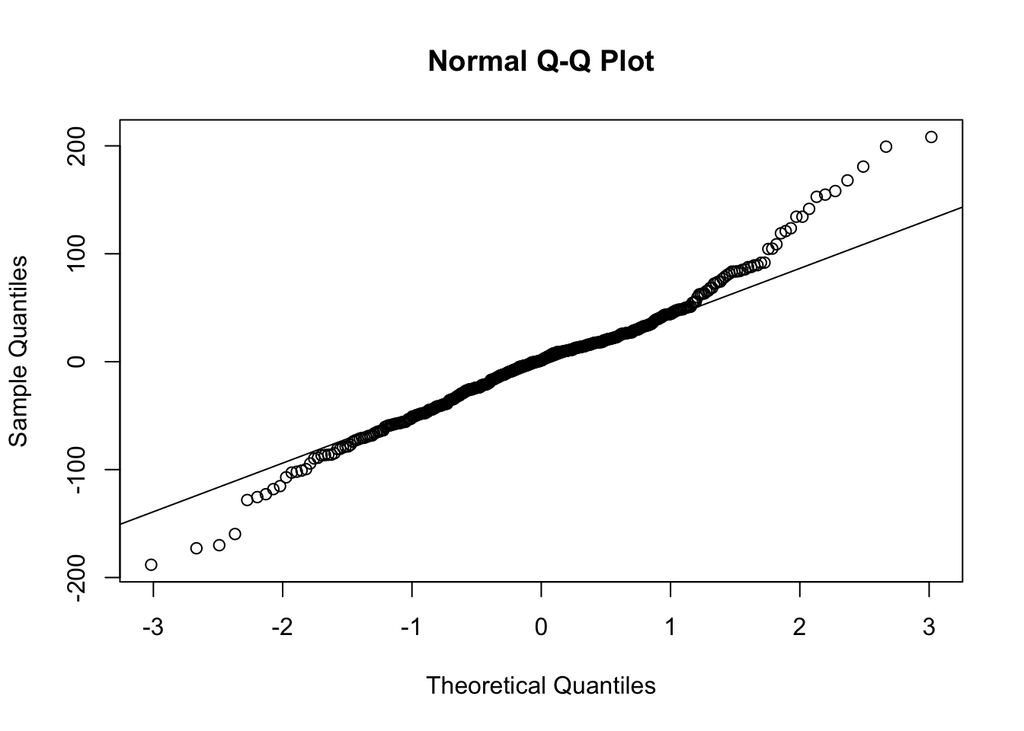

```r
qqnorm(modelo2$residuals)
qqline(modelo2$residuals)
```

7. Realice una prueba de hipótesis Breusch-Pagan. ¿Se rechaza la hipótesis nula? Justifique porque llegó a esa conclusión en la hipótesis

Con la prueba Breusch-Pagan, nuestra Ho existe homocedasticidad y H1 que no se presenta, con un intervalo de confianza de 95%. Donde el p-value, 0.4102 > 0.05, no se tienen pruebas suficientes para rechazar Ho

```r
library(lmtest)
bptest(modelo2)
```

```
##
##  studentized Breusch-Pagan test
##
## data:  modelo2
## BP = 2.8821, df = 3, p-value = 0.4102
```

8. ¿Existe multicolinealidad en el modelo? Defina porqué:

No se muestra multicolinealidad ya que los valores calculados de vif son menores a 5 por el intervalo de confianza.

```r
library(car)
vif(modelo2)
```

```
##     M$V1     M$V6     M$V7
## 1.688960 1.222795 1.513882
```

1. Realice un ANOVA para el modelo e interprete correctamente los resultados. ¿Cuál es el error estándar residual que arroja? Opine al respecto y redondee a 3 dígitos después del punto decimal:

No se puede realizar ANOVA ya que se rechazo Ho en shapiro, ya que se requiere una normalidad en los datos. Pero el summary nos dio el error estandar residual de 55.96.

Incluya su código y sus cálculos anotando el número de pregunta e inciso al que está respondiendo (no es necesario añadir la redacción del problema) y agregue sus comentarios (si se le solicitan en algún inciso) después de su implementación.

*Sugerencias:*

*Defina las hipótesis nulas como el caso afirmativo de que si se cumple la condición que se pregunta.* Utilice un nivel de significancia del 5% para las pruebas de hipótesis.

## Problema 3

Los datos se refieren al consumo de combustible del ciclo urbano en millas por galón (mpg) y 8 atributos (variables) de los automóviles. Los datos son los siguientes:

- V1. mpg: millas por galón
- V2. cilindros: número de cilindros
- V3. mileage: número de millas recorridas
- V4. horsepower: caballos de fuerza
- V5. weight: peso en libras
- V6. acceleration: aceleración
- V7. model_year
- V8. origin: nacional, extranjero, desconocido
- V9. car name: marca, tipo
1. Lea los datos y asegúrese que estén limpios. Reduzca la matriz de datos original a otra base si es necesario.

```r
M2 = read.csv("data2.3.csv")
M2
```

```
##       V1 V2  V3  V4   V5   V6 V7 V8                                   V9
## 1   18.0  8 398 215 4209 12.0 70  1            chevrolet chevelle malibu
## 2   15.0  8 492 133 3145 11.5 70  1                    buick skylark 320
## 3   18.0  8 371 139 2332 11.0 70  1                   plymouth satellite
## 4   16.0  8 117  93 3219 12.0 70  1                        amc rebel sst
## 5   17.0  8 200 148 4723 10.5 70  1                          ford torino
## 6   15.0  8 175 140 3311 10.0 70  1                     ford galaxie 500
## 7   14.0  8 243 168 3046  9.0 70  1                     chevrolet impala
## 8   14.0  8 225 149 2842  8.5 70  1                    plymouth fury iii
## 9   14.0  8 400  47 3221 10.0 70  1                     pontiac catalina
## 10  15.0  8 141 149 3750  8.5 70  1                   amc ambassador dpl
## 11    NA  4 469  77 2266 17.5 70  2                 citroen ds-21 pallas
## 12    NA  8  84 192 3298 11.5 70  1     chevrolet chevelle concours (sw)
## 13    NA  8 275 209 2524 11.0 70  1                     ford torino (sw)
## 14    NA  8 298 211 4162 10.5 70  1              plymouth satellite (sw)
```

[output cut: 392 more lines]

```r
sum(is.na(M2))
```

```
## [1] 8
```

```r
nrow(M2)
```

```
## [1] 406
```

```r
M2= na.omit(M2)
nrow(M2)
```

```
## [1] 398
```

```r
sum(is.na(M2))
```

```
## [1] 0
```

```r
M2Num = M2[,-9]
```

Existen 8 valores nulos los cuales se eliminaron y nos queda 398 pruebas.

2. Elija la variable V8 como variable dependiente, determine a través de análisis discriminante el análisis y responda a las siguientes preguntas:
1. Realice la implementación del modelo que incluya en principio todas las variables de la base para determinar su variable dependiente.

```r
library(klaR)
greedy.wilks(V8 ~., M2Num)
```

```
## Formula containing included variables:
##
## V8 ~ V2 + V1 + V7
## <environment: 0x7fb9d989d180>
##
##
## Values calculated in each step of the selection procedure:
##
##   vars Wilks.lambda F.statistics.overall p.value.overall F.statistics.diff
## 1   V2    0.6347596            227.85822    5.448672e-41         227.85822
## 2   V1    0.6098922            126.32773    3.867956e-43          16.10552
## 3   V7    0.5756180             96.82724    5.785536e-47          23.46005
##   p.value.diff
## 1 5.448672e-41
## 2 7.164984e-05
## 3 1.834421e-06
```

```r
modelo3 <- lda(V8 ~ V2+V1+V7 , data = M)
```

2. Obtenga los valores de la función discriminante utilizando el resultado de los coeficientes en el inciso a).

```r
modelo3$scaling
```

```
##           LD1
## V2 -0.4390472
## V1  0.1061919
## V7 -0.1263154
```

3. Considere la función discriminante y los grupos. ¿Cuál es el valor del umbral (criterio de decisión)? Redondee a dos dígitos después del punto decimal:
4. Genere la variable “clase.pred” con el criterio condicional de si los valores de la función discriminante están por encima del valor del inciso c) pertenecen al grupo 1. ¿Cual es la tasa de error del modelo considerando esta clase predicha? Considere los primeros 3 dígitos después del punto decimal:
5. Genere las predicciones del modelo y obtenga las probabilidades a posteriori de los grupos.

```r
predicciones = predict(modelo3)
predicciones$posterior
```

```
##              1           2
## 1   0.92864250 0.071357497
## 2   0.95822338 0.041776620
## 3   0.92864250 0.071357497
## 4   0.94997138 0.050028624
## 5   0.94019112 0.059808882
## 6   0.95822338 0.041776620
## 7   0.96516417 0.034835835
## 8   0.96516417 0.034835835
## 9   0.96516417 0.034835835
## 10  0.95822338 0.041776620
## 16  0.95822338 0.041776620
## 17  0.96516417 0.034835835
## 19  0.95822338 0.041776620
## 20  0.96516417 0.034835835
```

[output cut: 378 more lines]

6. Utilice nuevamente su modelo final considerando costos distintos de cero para los grupos (determine los que considere adecuados para el ejercicio). Muestre los resultados y matriz de confusión.
7. ¿Se logró segmentar? ¿Es buen discriminante para su predicción?

## Problema 4

Los siguientes datos corresponden a la contaminación del aire de la ciudad de los Ángeles en diferentes días con las siguientes variables:

- X1 = Wind
- X2 = Solar radiation
- X3 = CO
- X4 = NO
- X5 = NO2
- X6 = O3
- X7 = HC (hydrocarbons combustion)
1. Realice un análisis de normalidad de las variables continuas para identificar variables normales por pares y por distribución conjunta (se sugiere utilizar la prueba normalidad de Mardia y con prueba de Anderson Darling). Identifique las variables que resultaron leptocúrticas, platicúrticas y mesocúrticas.

Según la prueba de normalidad de Marbia no pasa la prueba de sesgo, pero si la de kurtosis. Los datos no se deistribuyen normal.

```r
library(moments)
pro4 = read.csv("airpollution.csv")
library(MVN)
mvn(data = pro4, mvnTest = "mardia")
```

```
## $multivariateNormality
##              Test        Statistic             p value Result
## 1 Mardia Skewness 129.215412365806 0.00112128950460133     NO
## 2 Mardia Kurtosis 1.14168278514876   0.253585898977204    YES
## 3             MVN             <NA>                <NA>     NO
##
## $univariateNormality
##               Test  Variable Statistic   p value Normality
## 1 Anderson-Darling    X1        0.9891  0.0118      NO
## 2 Anderson-Darling    X2        0.9623  0.0137      NO
## 3 Anderson-Darling    X3        2.3631  <0.001      NO
## 4 Anderson-Darling    X4        2.1283  <0.001      NO
## 5 Anderson-Darling    X5        0.6975  0.0636      YES
## 6 Anderson-Darling    X6        1.2030  0.0034      NO
## 7 Anderson-Darling    X7        3.9150  <0.001      NO
##
## $Descriptives
##     n      Mean    Std.Dev Median Min Max  25th  75th        Skew    Kurtosis
## X1 42  7.500000  1.5811388    8.0   5  10  6.00  8.75  0.03614032 -1.10809524
## X2 42 73.857143 17.3353881   76.5  30 107 68.25 84.75 -0.73323765  0.30901245
## X3 42  4.547619  1.2337209    4.0   2   7  4.00  5.00  0.57793497 -0.25497268
## X4 42  2.190476  1.0873574    2.0   1   5  1.00  3.00  0.62983752 -0.52220171
## X5 42 10.047619  3.3709837    9.5   5  21  8.00 12.00  0.98543943  1.22197318
## X6 42  9.404762  5.5658345    8.5   2  25  6.00 11.00  1.13370267  1.02388767
## X7 42  3.095238  0.6917466    3.0   2   5  3.00  3.00  0.31349052  0.04343283
```

```r
kurtosis(pro4)
```

```
##       X1       X2       X3       X4       X5       X6       X7
## 1.985318 3.472396 2.880564 2.600140 4.430435 4.222569 3.193703
```

2. Con el total de datos calcula la distancia de Mahalanobis de cada observación al centroide (vector de medias) con respecto a la matriz de covarianzas. ¿Qué observación está más alejada, según la distancia de Mahalanobis, del centroide? ¿Qué observación está más cercana?

```r
vMedia4 = colMeans(pro4)
S4 = cov(pro4)
Dm = mahalanobis(pro4, vMedia4, S4)
gl = ncol(pro4)
for(i in c(0.25, 0.5, 0.75)){
  prop = sum(Dm < qchisq(i,gl))/length(Dm)
  cat("Observado:",prop, "Esperado: ", i*100, "%\n")
}
```

```
## Observado: 0.4047619 Esperado:  25 %
## Observado: 0.547619 Esperado:  50 %
## Observado: 0.7380952 Esperado:  75 %
```

No muy similares, pero son cercanos.

3. Interprete los resultados de su análisis.

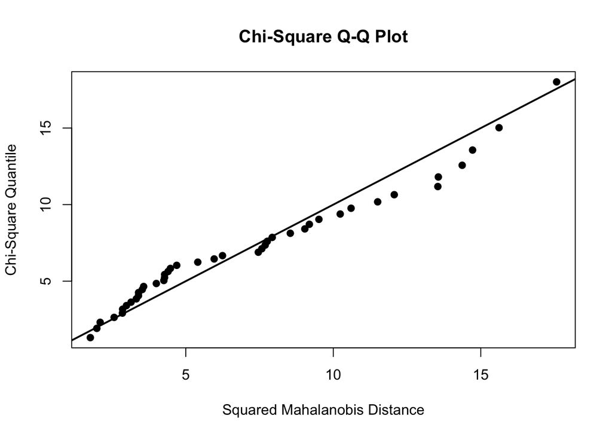

```r
test4 = mvn(data = pro4, multivariatePlot = "qq")
```

## Problema 5

Los siguientes datos corresponden a la contaminación del aire de la ciudad de los Ángeles en diferentes días con las siguientes variables:

- X1 = Wind
- X2 = Solar radiation
- X3 = CO
- X4 = NO
- X5 = NO2
- X6 = O3
- X7 = HC (hydrocarbons combustion)
1. Aplicar al total de datos un análisis de componentes principales y con base en al menos tres criterios (por ejemplo, porcentaje de variación acumulada, gráfica de Scree y los valores de las cargas) determinar cuántos componentes son suficientes para explicar razonablemente la mayoría de la variación.

B. Escribir las combinaciones lineales de los Componentes principales en función de las variables y cargas obtenidas de los componentes principales resultantes.

3. Utilizando los dos primeros componentes hacer una gráfica de dispersión de las puntuaciones. Comentar el gráfico en función de la variabilidad.

D. Hacer un gráfico vectorial de las variables e interpretar sus relaciones.

E. Interprete los resultados de su análisis.

## Problema 6

A continuación se muestran los records de mujeres en pruebas de velocidad corriendo de varios países.

COUNTRY = país

- X1 = segundos en carrera de 100 metros
- X2 = segundos en carrera de 200 metros
- X3 = segundos en carrera de 400 metros
- X4 = minutos en carrera de 800 metros
- X5 = minutos en carrera de 1500 metros
- X6 = minutos en carrera de 3000 metros
- X7 = minutos en carrera de maratón

**A.** Justifique por qué es adecuado el uso del Análisis factorial (hacer la prueba de esfericidad de Bartlett y KMO).

**B.** Justifique el número de factores principales que se utilizarán en el modelo.

**C.** dentifique las comunalidades de los factores del modelo propuesto, y los errores: interprete si se necesita un nuevo factor.

**D.** Encuentre con ayuda de un gráfico de variables qué conviene más sin rotación o con rotación varimax. (se puede ayudar con la función **fa** de la librería psych y el gráfico de la función **fa.diagram**)

**E**. Interprete los resultados de su análisis.

## Problema 7

A continuación se muestra las distancias por avión entre las siguientes ciudades:

[output not shown]

**A.** Hallar la matriz de ultra-distancias (dendrogram-dist) con el método de aglomeración jerárquica: (1) distancia mínima para nuevo grupo (2) distancia promedio entre individuos. Construir el dendrograma respectivo.

```r
library(factoextra)
Mpre7 = matrix(c(0,1068,606,461,805,508,0,0,867,769,1819,941,0,0,0,107,943,108,0,0,0,0, 1050,172,0,0,0,0,0,882,0,0,0,0,0,0), ncol = 6)
M7 = Mpre7 + t(Mpre7); M7
```

```
##      [,1] [,2] [,3] [,4] [,5] [,6]
## [1,]    0 1068  606  461  805  508
## [2,] 1068    0  867  769 1819  941
## [3,]  606  867    0  107  943  108
## [4,]  461  769  107    0 1050  172
## [5,]  805 1819  943 1050    0  882
## [6,]  508  941  108  172  882    0
```

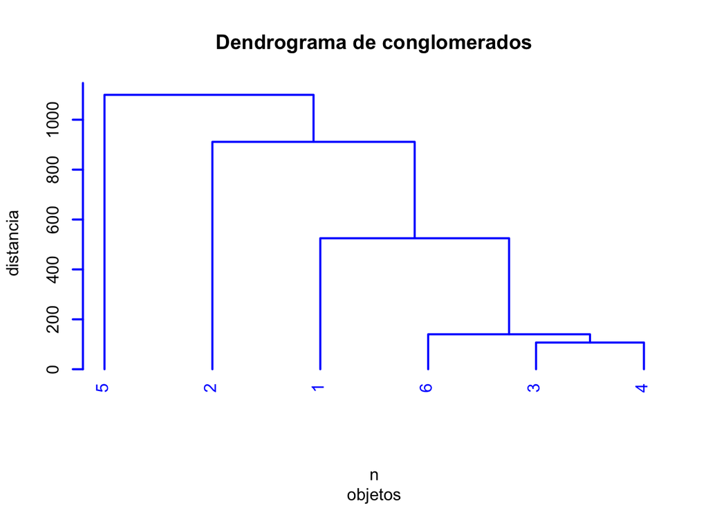

```r
d7 = as.dist(M7)
J = hclust(d7, method = "average")
plot(J, hang = -1, lwd = 2, col = "blue", main = "Dendrograma de conglomerados", sub = "objetos", xlab = "n",ylab = c("distancia"))
```

**B.** Interprete los resultados de su análisis.

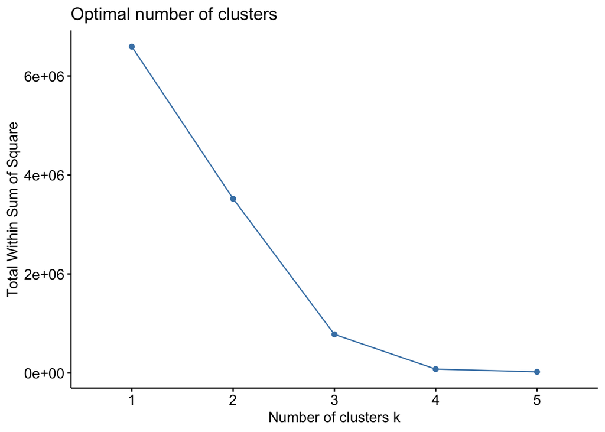

```r
fviz_nbclust(M7, FUNcluster = kmeans, method = "wss", k.max = 5)
```